# LD of short stories in Spanish-speaking authors

Juan Felipe Castro Cárdenas

10/16/2019

# Introduction

The idea of this document is to compare the work of various Spanish-speaking authors to establish a computational value for the complexity of their texts. For the moment, the only complexity criterion applied is Lexical Diversity (LD), a relatively simple criterion which is usually important for the choice of texts to be read by children and foreign learners of a language. Other more sophisticated features of a text (sentence structure, use of tenses and modes, …) should be later incorporated.

# Consitution of a corpus

In order to compare a significant number of authors, we need to constitute a large corpus. For this analysis, we have retrieved texts by 138 Spanish-speaking authors from the website https://ciudadseva.com/biblioteca/indice-autor-cuentos/, which contains many stories written in or translated into Spanish, mainly by modern (born post-1800) authors. These texts are well transcribed, with a feeble proportion of errors, and represent all countries of Iberoamerica (though mainly Spain, Mexico and Argentina, which are by far the biggest contributors to the Spanish literary corpus). The website layout is simple enough that it allows for the utilization of basic webscraping techniques for the consultation and download from these pages. The code to recover the texts is shown in the next chunk; Docker is needed by RSelenium to deploy the selenium/standalone-firefox automatic navigator which performs the actual recovery of text.

```r
# eval = FALSE since the execution of this chunk requires a significant amount of resources
# from a home computer. The execution has already been done and results saved in the
# Resources folder in the root directory.

#' Setup and run our automated Firefox navigator.
#' For more information, see vignette("docker", "RSelenium").
shell("docker run -d -p 4445:4444 selenium/standalone-firefox")
remDr <- remoteDriver(remoteServerAddr = "192.168.99.101", port = 4445L)
remDr$open()
remDr$navigate("https://ciudadseva.com/biblioteca/indice-autor-cuentos/")

#' Recover author metadata
#' (CSS selector recovered through ChroPath on Firefox)
author_selector <- "body.page-template.page-template-template-index-authors.page-template-template-index-authors-php.page.page-id-46566.page-child.parent-pageid-3416.indice-autor-cuentos.sidebar-primary:nth-child(2) div.container-fluid:nth-child(11) div.col-sm-8.col-white:nth-child(2) div.row.xs-center:nth-child(7) div.col-sm-6"
all_authors.webEls <- remDr$findElements("css selector", author_selector)
all_authors.links <-  all_authors.webEls %>%
                      map(~.$findChildElement("tag name", "a")$getElementAttribute("href")) %>%
                      unlist()
all_authors.names <-  all_authors.webEls %>%
                      map(~str_match(.$getElementText(), "(.*): \n(.*): ([0-9]{4})-([0-9]{4})")) %>%
                      reduce(rbind) %>%
                      as_tibble() %>%
                      select(-1) %>%
                      rename("Autor" = 1, "País" = 2, "Nacimiento" = 3, "Defunción" = 4)
all_authors.links <- all_authors.links[which(!is.na(all_authors.names$Autor))]
all_authors.names <- all_authors.names %>%
                     filter(!is.na(Autor))

if (!dir.exists("Resources")){dir.create("Resources")}
write_csv2(all_authors.names, "Resources/Todos los autores.csv")
saveRDS(all_authors.links, "Resources/all_authors_links.rds")

#' Identify only iberoamerican authors
Iberoamerican_countries <- c("Colombia", "España", "México", "Perú",
                             "Puerto Rico", "Argentina", "Cuba", "Guatemala",
                             "Paraguay", "Chile", "Uruguay",
                             "Venezuela", "República Dominicana", "Honduras",
                             "Nicaragua", "Costa Rica", "Bolivia", "El Salvador",
                             "Ecuador", "Panamá")
all_authors.names <- all_authors.names %>%
                     mutate(País = str_replace_all(País, c("Española" = "España",
                                                           "Mexicana" = "México",
                                                           "Argentino" = "Argentina",
                                                           "Mexicano" = "México",
                                                           "Puertorriqueño" = "Puerto Rico",
                                                           "Boliviano" = "Bolivia")))
sp_authors.links <- all_authors.links[which(all_authors.names$País %in% Iberoamerican_countries)]
sp_authors.names <- all_authors.names %>%
                    filter(País %in% Iberoamerican_countries)

write_csv2(sp_authors.names, "Resources/Autores en español.csv")
saveRDS(sp_authors.links, "Resources/sp_authors_links.rds")

#' Now follow the links to recover each one's tales.
#' Xpath retrieved thanks to ChroPath
tales_xpath <- "/html[1]/body[1]/div[7]/div[2]/article[1]/div[1]/ul[1]"

#' find_tales_links
#' @description Internal function for retrieving the links to the stories
#' @return Named list of links to the different tales by the author.
find_tales_links <- function(author.link) {

  tryCatch({
  remDr$navigate(author.link)
  cat(paste0("Visiting ", str_match(author.link, "autor/([a-z\\-]*)/cuentos/")[[2]], "\n"))
  tales_elements <- remDr$findElement("xpath", tales_xpath)$findChildElements("tag name", "li")
  tales_links <- tales_elements %>%
                 map(~.$findChildElement("tag name", "a")$getElementAttribute("href"))
  tales_names <- tales_elements %>%
                 map_chr(~unlist(.$getElementText()))
  names(tales_links) <- tales_names
  return(tales_links)
  },
  error = function(e) {print(e); return(NULL)})
}

#'#' This is a bit more concise, but more risky if the machine eventually fails,
#'#' for the time needed to navigate all these websites is non-negligeable with
#'#' a home computer.
#' sp_authors.tales_links <- sp_authors.links %>%
#'                           map(find_tales_links)

sp_authors.tales_links <- list()
for (author.link in sp_authors.links) {
  sp_authors.tales_links <- c(sp_authors.tales_links, list(find_tales_links(author.link)))
}
names(sp_authors.tales_links) <- sp_authors.names$Autor
saveRDS(sp_authors.tales_links, "Resources/sp_authors_tales_links.rds")


sp_authors.names$Cuentos <- sp_authors.tales_links %>%
                            map_chr(~paste0(names(.), collapse = ", "))

write_csv2(sp_authors.names, "Resources/Autores en español y cuentos.csv")

#' Having the links, we can finally recover the texts. This could be a heavier
#' operation than retrieving the links.
#' (The Xpath for the body of the text has been discovered through ChroPath.)
text_path <- "/html[1]/body[1]/div[7]/div[2]/article[1]/div[1]"

text_list <- list()
remDr$open()
for (author in names(sp_authors.tales_links)) {

  cat(paste0("Retrieving texts by ", author, "\n"))
  author_texts <- c()
  tryCatch({
  for (tale_link in sp_authors.tales_links[[author]]){
      remDr$navigate(tale_link[[1]])
      tryCatch({tale <- remDr$findElement("xpath", text_path)$getElementText()},
               error = function(e) {print(e); tale <- NA})
      author_texts <- append(author_texts, tale)
      names(author_texts) <- names(sp_authors.tales_links[[author]])
  }}, error = function(e) {print(e); author_texts <- NULL})
  text_list <- c(text_list, list(author_texts))
}
rm(tale, author.link)
rm(author)

names(text_list) <- sp_authors.names$Autor[sp_authors.names$Cuentos != ""]
saveRDS(text_list, "Resources/text_list.rds")
```

We list all tales recovered, since some of those available were not recovered due to technical problems at the time of the request (but the great majority were). Only the texts of Juan Manuel and Max Aub were omitted from the list, in the first case because layout differences invalidate the Xpath, and also because his Spanish is particularly archaic, and in the second because his double nationality was not recognized among the Iberoamerican countries. Some of the texts by Emilia Pardo Bazán, 275 in total, were not recovered; the 110 which were already present a significant corpus for a single author.

```r
if (!exists("text_list")) {
  text_list <- readRDS("Resources/text_list.rds")
}

try({tales_frame <- readRDS("Resources/tales_frame_final.rds")})
if (!exists("tales_frame")) {
tales_frame <- map(names(text_list), function(author) {

              #' Año : Year of writing appears sometimes as the last word of the document.
              tibble(Título = names(text_list[[author]]),
                     Autor  = author,
                     Año = stri_reverse(str_match(stri_reverse(unlist(text_list[[author]])),"([0-9]{4})")[, 2]))
                }) %>%
                bind_rows()

}
```

We now have a total of 1198 short stories to start analyzing the way these authors utilize the Spanish language.

# Corpus Analysis

As a first information, we will see which are the most frequent words overall.

```r
# We omit Spanish ponctuation and symbols, and numbers which may be collated to words.
ponctuation <- "[\\-\\—\\‑\\…\\¡\\!\\_\\?\\¿\\,\\.\\:\\;\\'«»\\)\\(\\[\\]\\$|[:punct:]|[:digit:]|\\+\\=\\<\\>\\°]"

word_splicing.by_author <- function(author){
  cat(paste0(author, "\n"))
  spl_text <- map(unlist(text_list[[author]]), ~strsplit(., "\\n| "))
  spl_text <- c(unlist(spl_text))
  return(spl_text)
}

sp_authors.all_spliced <- names(text_list) %>%
                          map(word_splicing.by_author) %>%
                          unlist() %>%
                          c()
```

```r
sp_authors.all_spliced <- str_replace_all(sp_authors.all_spliced, ponctuation, "")
saveRDS(sp_authors.all_spliced, "Resources/sp_authors_all_spliced.rds")

sp_authors.all_spliced.factor <- sp_authors.all_spliced %>%
                                 tolower() %>%
                                 factor()

sort(table(sp_authors.all_spliced.factor), decreasing = T)[1:100]
```

```
## sp_authors.all_spliced.factor
##       de       la        y      que       el        a       en       se
##   119521    85332    83017    76146    64035    55977    51899    32599
##      los       no       un      con      las       su      por      del
##    32581    30384    28054    24792    23341    22903    21077    20012
##      una       al       lo       le       me     como     para      más
##    19666    16876    16334    14011    13736    12296    11166    10440
##      sus             había       es     pero      era       mi       yo
##     9384     9180     8878     8809     8646     8430     7679     7498
##       si      sin       ya   cuando       él      qué        o       ni
##     7209     6824     5991     5850     5460     5350     5219     4792
##     todo     ella    sobre   porque      tan    hasta   estaba      dos
##     4398     4329     4267     4163     4162     3967     3875     3706
##     dijo     ojos      muy      fue      vez    entre     casa  después
##     3533     3487     3436     3352     3309     3264     3118     3081
##     bien      así    tenía      día       te       ha    usted    todos
##     3012     3002     2941     2908     2907     2879     2855     2805
##      nos   hombre    noche    donde      fin     otro      ser    mujer
##     2714     2702     2686     2657     2642     2613     2609     2607
##    aquel     pues     nada     este    mismo       sí   tiempo     esta
##     2415     2390     2353     2347     2338     2320     2318     2302
##    desde     poco     vida    ahora  siempre entonces     allí     otra
##     2300     2254     2237     2233     2219     2198     2166     2136
##      eso  aquella  también      uno   cabeza       mí      ese     esto
##     2106     2088     2013     2004     1986     1980     1972     1951
##      mis      hay     mano      ver
##     1946     1930     1929     1927
```

```r
commonest <- names(sort(table(sp_authors.all_spliced.factor), decreasing = T)[1:49])

print(paste0("Las 49 palabras más comunes representan ", 100*(sum(sort(table(sp_authors.all_spliced.factor), decreasing = T)[1:49])/sum(table(sp_authors.all_spliced.factor))), "% de la muestra."))
```

```
## [1] "Las 49 palabras más comunes representan 45.0184642706711% de la muestra."
```

Surprisingly enough, “ojos” (eyes) is the most common substantive throughout this corpus! It is followed by “casa” (house, home), a word which would be much more credible as judging from the spoken language.

We can now compare the LD for these different authors. A couple of anotations, however :

- The different inflected forms of substantives, adjectives and verbs are here counted as different words. In Spanish, each verb has many tens of conjugated forms in common use which would here be counted as different words. This could be a limitation, and I am looking for a dictionary in database form that would allow me to associate each inflected form to a parent form (I do not know if such a dictionary already exists in that format for Spanish). On the other hand, the use of many different tenses and modes for a verb reflects in itself some different kind of linguistical complexity to be studied.
- Some ortographical errors are also to beware. On the site consulted, they tend to be really few. There are also ortographical variants that may be considered in a further comparison, by country for example, but since the authors are modern the general ortography of Spanish is common to them all.

Now, the most intuitive metric of LD is obtained by counting the proportion of distinct words in a text. This is actually called TTR (Type-Token Ratio) by linguists, and is readily computed.

```r
try({texts <- readRDS("Resources/texts.rds")})
if (!exists("texts")) {
texts <- unlist(map(text_list, unlist))
saveRDS(texts, "Resources/texts.rds")
}
if (!("Palabras" %in% names(tales_frame))){
tales_frame$Palabras <- names(texts) %>%
  map_dbl(~length(strsplit(texts[[.]], "\\n| ")[[1]]))
}
if (!("TTR" %in% names(tales_frame))) {
tales_frame$TTR <- names(texts) %>%
                   map(~strsplit(texts[[.]], "\\n| ")[[1]]) %>%
                   map(~str_replace_all(., ponctuation, "")) %>%
                   map_dbl(~length(unique(.))/length(.))
}
print(paste0("Correlation between the TTR and text length is: ",
             cor(tales_frame$TTR, tales_frame$Palabras)))
```

```
## [1] "Correlation between the TTR and text length is: -0.430129342919197"
```

We see that, according to this calculation, long stories present a feebler lexical diversity compared with shorter ones. This seems very doubtful and, indeed, this way to measure LD is not considered of much use by modern linguists : as the number of words sampled grows, they will almost forcefully become less diverse, since the lexicon of any language is limited. In th computational linguistics a better indicator has been developed, the Measure of Textual Lexical Diversity (MTLD).

***Reference 1**: See https://www.ncbi.nlm.nih.gov/pmc/articles/PMC3813439/ for an examination of the different metrics which are used to assess the impact of aphasia on lexical diversity.

***Reference 2** : In https://link.springer.com/content/pdf/10.3758%2FBRM.42.2.381.pdf the creator of the MTLD metric explains the method and its rationale in detail.

```r
# Auxiliary function
factor_counting <- function(word.sample, factor.size, reverse = F) {
  total_length <- length(word.sample)
  if (reverse) {word.sample <- rev(word.sample)}
  factor_count <- 1
  while (length(word.sample)>1) {
    for (i in 1:length(word.sample)) {
      TTR <- length(unique(word.sample[1:i]))/i
      if (TTR<factor.size | i==length(word.sample)) {
        partial_factor <- ifelse(TTR<factor.size, 1, (1-TTR)/(1-factor.size))
        factor_count <- factor_count+partial_factor
        word.sample <- word.sample[min(i+1, length(word.sample)):length(word.sample)]
        break
      }
    }
  }
  return(total_length/factor_count)
}

# Actual metric calculation
MTLD <- function(word.sample, factor.size = 0.72) {
  word.sample <- str_replace_all(word.sample, ponctuation, "")
  word.sample <- word.sample[!(word.sample %in% "")]
  if (length(word.sample) == 1) {
    word.sample <- strsplit(word.sample, "\\n| ")[[1]]
    return(ifelse(length(word.sample)==1, 1, MTLD(word.sample, factor.size)))
  }
  else {
    direct_value <- factor_counting(word.sample, factor.size)
    reverse_value <- factor_counting(word.sample, factor.size, reverse = T)
    return(mean(c(direct_value, reverse_value)))
  }
}

if (!("MTLD" %in% names(tales_frame))) {
tales_frame$MTLD <- names(texts) %>%
                    map_dbl(function(tale) {print(tale); MTLD(texts[[tale]])})
}
```

We can then answer a question difficult to answer otherwise : which classical spanish-speaking author has the greatest average linguistical diversity?

**N.B.** We exclude the stories with less than a hundred words, which are not so well covered by the index or represent recovery mistakes (in the case of Borges’s texts, we have sometimes only retrieved the citation at the introduction due to the formatting of the page being different).

```r
lexical_diversity.by_author <- tales_frame %>%
                               filter(Palabras>100) %>%
                               group_by(Autor) %>%
                               summarise_at(vars(MTLD), ~mean(.)) %>%
                               arrange(1/MTLD)
```

```r
MTLD.non_commonest <- function(word.sample, factor.size=0.72) {
  if (length(word.sample) == 1) {
    word.sample <- strsplit(word.sample, "[\\n ]", perl = T)[[1]]
    return(ifelse(length(word.sample)==1, 1, MTLD.non_commonest(word.sample, factor.size)))
  }
  else {
    word.sample <- word.sample[which(!(word.sample %in% commonest))]
    MTLD(word.sample, factor.size)
  }
}

if (!("MTLD.not_commonest" %in% names(tales_frame))) {
tales_frame$MTLD.not_commonest <- names(texts) %>%
  map_dbl(function(tale) {print(tale); MTLD.non_commonest(texts[[tale]])})
}
```

This value is much higher, but it is also much more related to longitude of text : that is, if we exclude the repetition of this 49 “commonest” words, it seems that the lexical diversity of a text would very much increase in size, at least for these literary texts.

```r
print(paste0("Correlación sin excluir palabras: ", cor(tales_frame$MTLD,
                                                         tales_frame$Palabras)))
```

```
## [1] "Correlación sin excluir palabras: 0.260166336890689"
```

```r
print(paste0("Correlación sin las palabras más comunes: ", cor(tales_frame$MTLD.not_commonest, tales_frame$Palabras)))
```

```
## [1] "Correlación sin las palabras más comunes: 0.668269065200046"
```

Clearly all classical authors are wary of repetition! More interesting, however, is to note that this correlation coefficient weakly grows when shorter texts are excluded, while the original MTLD decays rapidly :

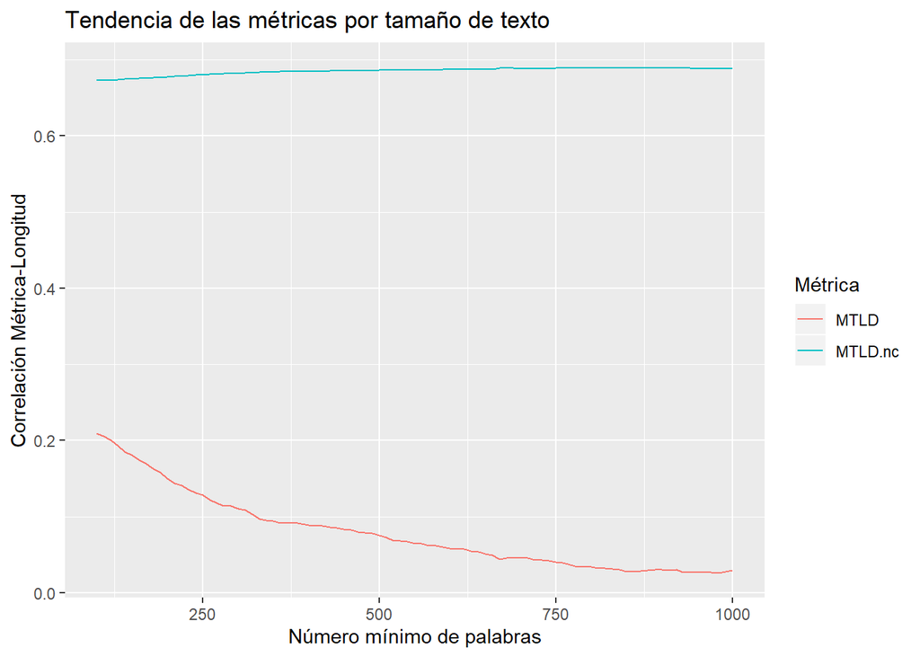

```r
Palabras_vs_MTLD <- map_dbl(seq.int(100, 1000, 10), ~cor(filter(tales_frame, Palabras > .)$Palabras,
                                                         filter(tales_frame, Palabras > .)$MTLD))
Palabras_vs_MTLD.nc <- map_dbl(seq.int(100, 1000, 10), ~cor(filter(tales_frame, Palabras > .)$Palabras,
                                                         filter(tales_frame, Palabras > .)$MTLD.not_commonest))

tibble(min_words = seq.int(100, 1000, 10), MTLD = Palabras_vs_MTLD, MTLD.nc = Palabras_vs_MTLD.nc) %>%
  gather(key = "Métrica", value = "MTLDs", -min_words) %>%
  ggplot(aes(x = min_words, y = MTLDs, color = Métrica)) +
  geom_line() +
  labs(title = "Tendencia de las métricas por tamaño de texto",
       x = "Número mínimo de palabras",
       y = "Correlación Métrica-Longitud")
```

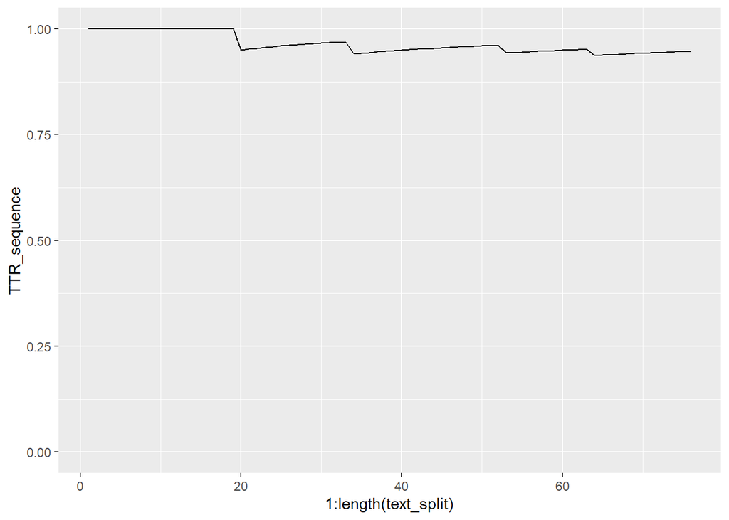

```r
text_split<-strsplit(str_replace_all(texts[[120]], ponctuation, ""), "\\n| ")[[1]]
text_split <- text_split[which(!(text_split %in% commonest))]
TTR_sequence <- map_dbl(1:length(text_split), ~length(unique(text_split[1:.]))/.)

qplot(x = 1:length(text_split), y = TTR_sequence, geom = "line", ylim = c(0,1))
```

We see that TTR first varies much, then its variation becomes very gradual until it just gradually decreases. At this point, we should consider LD has unfolded to its possibilities. The idea then, would be as follows :

- We take 200-word fragment from our corpus (we consider this, from our previous use of MTLD, a more than sufficient margin for LD to deploy itself).
- We read the text and calculate the TTR at each new word, as well as the change from the TTR level just before
- We keep a window with the last 20 words, and we stop at the point were there has not been any jump of more than 0.005 in the TTR levels (this way, variation has stabilized at less than 0.005*20 = 0.1 at this point of text.)
- When we stop, we take the value of TTR as a value that corresponds to a point of stabilization : from this point onwards, the main tendency of TTR is a gradual descent, and we may consider that LD has fully deployed itself in the past fragment.

We hope to obtain in this way a significant value for TTR to work as factor.size, according to the rationale exhibited in Reference 2 above. We also expect this to be a value greater than 0.72, of course, since we have seen that this value is relatively high and produces a MTLD correlated with length for shorter texts (though little correlated for longer texts.)

```r
find_stabilization <- function(text, tol = 0.05, text_length = 200, window_length = 20) {
  if (length(text) == 1){
    text <- str_replace_all(text, ponctuation, "")
    split_text <- strsplit(text, "\\n| ")[[1]]
    return(ifelse(length(split_text) == 1, NA,
                  find_stabilization(split_text, tol, text_length, window_length)))
  }
  else {
    split_text <- str_replace_all(text, ponctuation, "")
    split_text <- split_text[!(split_text %in% "")]
  }
  if (length(split_text)<text_length) {return(NA)}
  big_jump <- rep(TRUE, window_length)
  word_count <- 1
  TTR <- 1
  while (any(big_jump) & word_count < text_length) {
    new_TTR <- length(unique(split_text[1:word_count]))/word_count
    if (abs(TTR-new_TTR) > tol) {big_jump <- c(big_jump[-1], TRUE)}
    else {big_jump <- c(big_jump[-1], FALSE)}
    TTR <- new_TTR
    word_count <- word_count+1
  }
  return(ifelse(word_count==text_length, NA, TTR))
}

stabilization_points <- c()
for (text in texts) {

  text <- str_replace_all(text, ponctuation, "")
  split_text <- strsplit(text, "\\n| ")[[1]]
  fragments <- split(split_text, ceiling((1:length(split_text))/200))
  stabs <- map_dbl(fragments, find_stabilization)
  stabilization_points <- c(stabilization_points, mean(stabs, na.rm = T))
}

stabilization_points2 <- c()
for (text in texts) {

  text <- str_replace_all(text, ponctuation, "")
  split_text <- strsplit(text, "\\n| ")[[1]]
  fragments <- split(split_text, ceiling((1:length(split_text))/200))
  stabs <- map_dbl(fragments, find_stabilization, tol = 0.01)
  stabilization_points2 <- c(stabilization_points2, mean(stabs, na.rm = T))
}

stabilization_points3 <- c()
for (text in texts) {

  text <- str_replace_all(text, ponctuation, "")
  split_text <- strsplit(text, "\\n| ")[[1]]
  fragments <- split(split_text, ceiling((1:length(split_text))/200))
  stabs <- map_dbl(fragments, find_stabilization, tol = 0.005, window_length = 20)
  stabilization_points3 <- c(stabilization_points3, mean(stabs, na.rm = T))
}
```

```r
if (!("MTLD_0.88" %in% names(tales_frame))) {
tales_frame$MTLD_0.88 <- tales_frame$MTLD <- names(texts) %>%
                         map_dbl(function(tale) {print(tale); MTLD(texts[[tale]],0.88)})
}

if (!("MTLD_0.8" %in% names(tales_frame))) {
tales_frame$MTLD_0.8 <- tales_frame$MTLD <- names(texts) %>%
                         map_dbl(function(tale) {print(tale); MTLD(texts[[tale]], 0.8)}) }

if (!("MTLD_0.76" %in% names(tales_frame))) {
tales_frame$MTLD_0.76 <- tales_frame$MTLD <- names(texts) %>%
                         map_dbl(function(tale) {print(tale); MTLD(texts[[tale]],0.76)}) }

print(paste0("Correlación MTLD al número de palabras con parámetro 0.88: ", cor(tales_frame$MTLD_0.88, tales_frame$Palabras)))
```

```
## [1] "Correlación MTLD al número de palabras con parámetro 0.88: 0.124199344295511"
```

```r
print(paste0("Correlación MTLD al número de palabras con parámetro 0.8: ", cor(tales_frame$MTLD_0.8, tales_frame$Palabras)))
```

```
## [1] "Correlación MTLD al número de palabras con parámetro 0.8: 0.197353818424097"
```

```r
print(paste0("Correlación MTLD al número de palabras con parámetro 0.76: ", cor(tales_frame$MTLD_0.76, tales_frame$Palabras)))
```

```
## [1] "Correlación MTLD al número de palabras con parámetro 0.76: 0.224090912912273"
```

```r
print(paste0("Correlación MTLD al número de palabras con parámetro 0.72: ", cor(tales_frame$MTLD, tales_frame$Palabras)))
```

```
## [1] "Correlación MTLD al número de palabras con parámetro 0.72: 0.260166336890689"
```

```r
if (!file.exists("Resources/tales_frame_final.rds")) {
saveRDS(tales_frame, "Resources/tales_frame_final.rds")
}
```

```r
lexical_diversity.by_author.revisited <- tales_frame %>%
                                         filter(Palabras>100) %>%
                                         group_by(Autor) %>%
                                         summarise_at(vars(MTLD_0.76), ~mean(.)) %>%
                                         arrange(1/MTLD_0.76)

lexical_diversity.by_author.revisited
```

```
## # A tibble: 136 x 2
##    Autor                  MTLD_0.76
##    <chr>                      <dbl>
##  1 Edwards, José              113.
##  2 Sinán, Rogelio             112.
##  3 Ayala, Francisco           104.
##  4 Guzmán, Augusto             98.6
##  5 Güiraldes, Ricardo          97.2
##  6 Barreto, Héctor             97.0
##  7 Pocaterra, José Rafael      96.3
##  8 Lugones, Leopoldo           95.4
##  9 Garmendia, Julio            94.2
## 10 Ribeyro, Julio Ramón        93.2
## # ... with 126 more rows
```

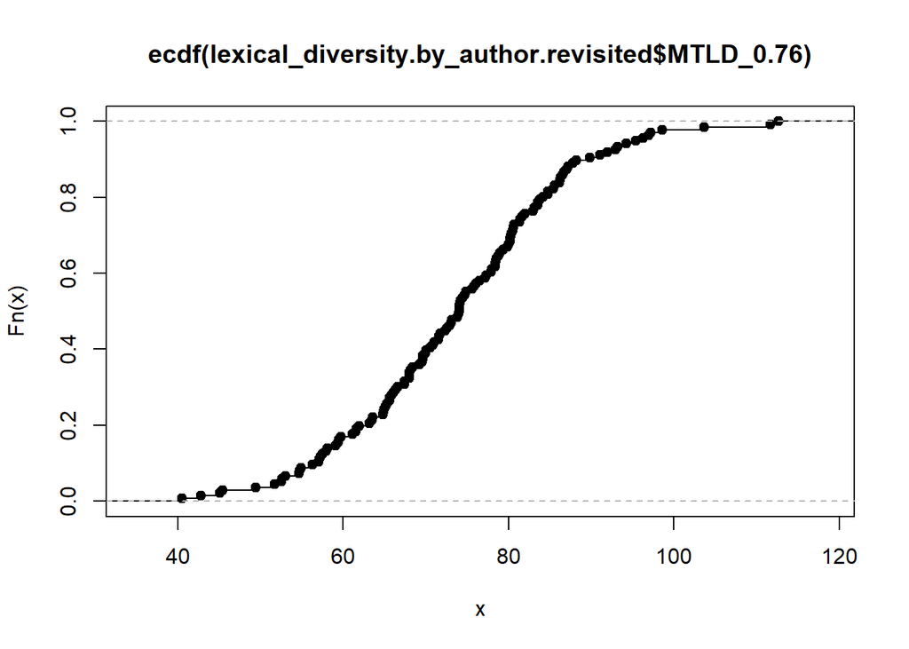

```r
plot(ecdf(lexical_diversity.by_author.revisited$MTLD_0.76))
```

```r
if (!file.exists("Resources/lexical_diversity.by_author.revisited.rds")) {
saveRDS(lexical_diversity.by_author.revisited, "Resources/lexical_diversity.by_author.revisited.rds")
}
```